# hw5

b03801053公衛四劉倢如

2017年11月28日

此筆資料是政府開放資料中，桃園市嫌疑犯人數與不同性別、不同教育程度的統計資料

```r
library(dplyr)
```

```r
library(ggplot2)
library(magrittr)
#匯入資料
dta <-  read.csv(file = "m_edu.csv", header = TRUE)
```

```r
#整理資料，把嫌疑犯人數都換成數值資料
dta$count <- as.numeric(dta$count)
```

```r
#看資料基本統計
summary(dta)
```

```
##       year         e_clasee      sex          count
##  Min.   : 89   大專    :45   女    :120   Min.   :  1.0
##  1st Qu.: 92   不識字  :45   全性別:120   1st Qu.: 63.0
##  Median : 96   自修    :45   男    :120   Median :119.0
##  Mean   : 96   其他    :45                Mean   :121.9
##  3rd Qu.:100   研究所  :45                3rd Qu.:180.2
##  Max.   :103   高中(職):45                Max.   :251.0
##                (Other) :90
```

想看看此筆資料性別對嫌疑犯人數的影響；以及最高教育程度與嫌疑犯人數的關係

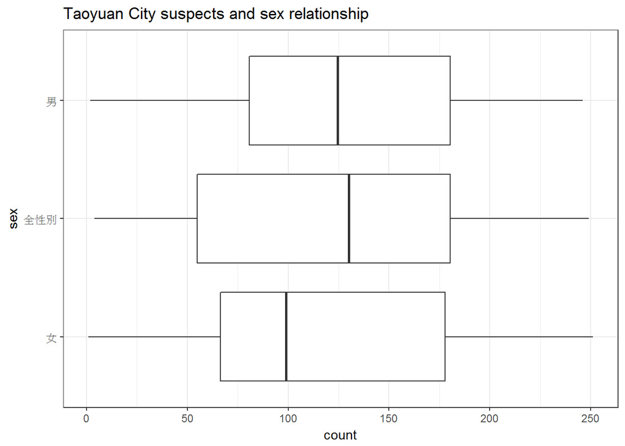

```r
#載進 ggplot2 準備畫圖
require(ggplot2)
#底下的圖都用黑白配色（theme_bw）
old <- theme_set(theme_bw())
#看不同性別的盒鬚圖
ggplot(data = dta, aes(x = sex, y = count)) +
  geom_boxplot() + coord_flip() +
  labs( y = 'count', x = 'sex',
        title = 'Taoyuan City suspects and sex relationship')
```

發現男性的嫌疑犯人數高於女生

```r
#只看男女兩性別
dta1 <-  dta[-which(dta$sex=="全性別"),]
#檢驗兩組樣本的母體變異數
#H0:兩組樣本的母體變異數相等
var.test(dta1$count[dta1$sex=="女"],dta1$count[dta1$sex=="男"])
```

```
##
##  F test to compare two variances
##
## data:  dta1$count[dta1$sex == "女"] and dta1$count[dta1$sex == "男"]
## F = 1.0917, num df = 119, denom df = 119, p-value = 0.6329
## alternative hypothesis: true ratio of variances is not equal to 1
## 95 percent confidence interval:
##  0.7608621 1.5664777
## sample estimates:
## ratio of variances
##            1.09173
```

p-value=0.6329>0.05故無法拒絕虛無假說，因此假設兩組樣本的母體變異數相等

利用t檢定分析

```r
#以t檢定比較不同性別的嫌疑犯數量差異
#變異數同值下的 t 檢定
#H0:男生的嫌疑犯人數比女生多
t.test(dta1$count~factor(dta1$sex))
```

```
##
##  Welch Two Sample t-test
##
## data:  dta1$count by factor(dta1$sex)
## t = -1.6744, df = 237.54, p-value = 0.09537
## alternative hypothesis: true difference in means is not equal to 0
## 95 percent confidence interval:
##  -33.029342   2.679342
## sample estimates:
## mean in group 女 mean in group 男
##         114.6583         129.8333
```

```r
#整理資料
#將不同教育程度者，加總嫌疑犯人數
a <- select(dta1,year,e_clasee,count,sex) %>%
        group_by(e_clasee)
#重新命名欄位名稱
colnames(a) <-c("year","edu","count","gender")
```

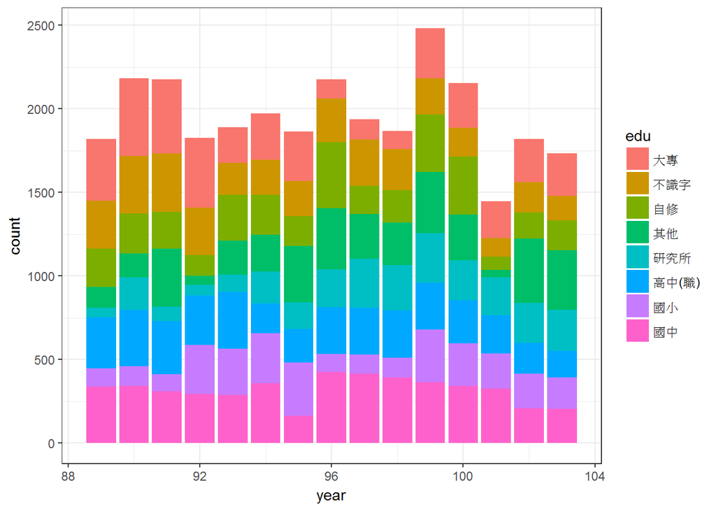

```r
ggplot(a, aes(x=year, y=count,fill=edu)) + geom_bar(stat="identity")
```

可以看出不同年份，不同教育程度的嫌疑犯人數增減的情形，整體來說，若以研究所的情況來看，其嫌疑犯人數在96年以後的人數都差不多，但還是比96年前還多，此外歷年來則是在99年統計到的嫌疑犯人數是最多的

看不同教育程度下的嫌疑犯平均數

```r
tapply(a$count, a$edu, mean)
```

```
##      大專    不識字      自修      其他    研究所  高中(職)      國小
## 137.56667 116.10000 112.20000 125.00000  96.13333 131.13333 101.26667
##      國中
## 158.56667
```

最高教育程度在國中者，平均所算出來的嫌疑犯人數最高

看不同教育的嫌疑犯人數差異，以圖來表示

```r
#不同教育程度
a$edu <- factor(a$edu, levels = c('不識字',
                                            '自修',
                                            '國小',
                                            '國中',
                                            '高中(職)','大專','研究所','其他'))
library(Hmisc)
```

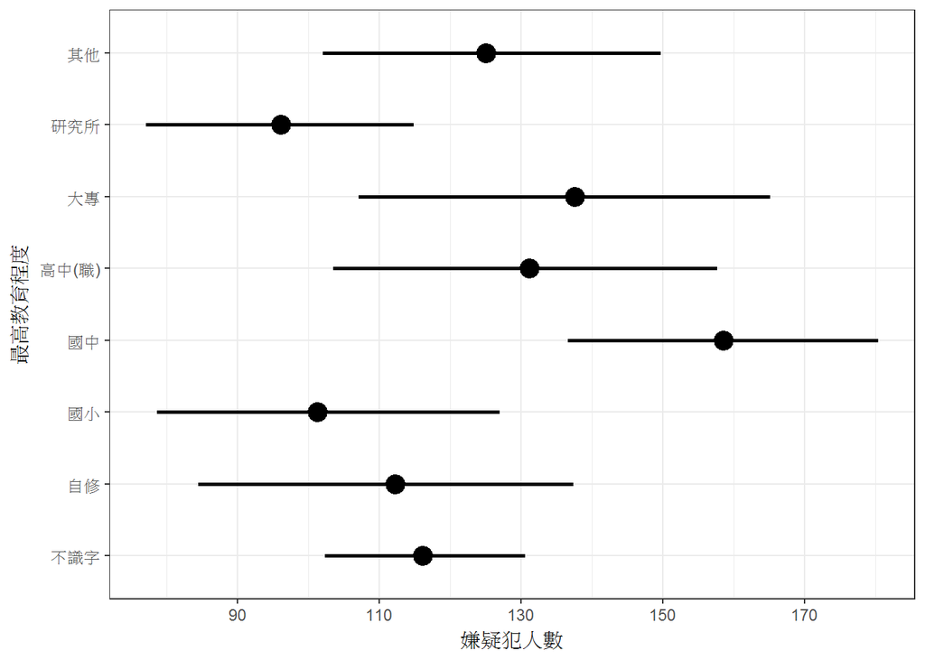

```r
ggplot(data = a,
       aes(x = edu, y = count))+
  stat_summary(fun.data = 'mean_cl_boot', size = 1) +
  scale_y_continuous(breaks = seq(90, 200, by = 20))+
  geom_hline(yintercept = mean(a$edu) ,
             linetype = 'dotted') +
  labs(x = '最高教育程度', y = '嫌疑犯人數') +
  coord_flip()
```

情況如同平均數的呈現

```r
#因為教育程度有多種類別，用anova檢定
#H0:最高教育程度不同對嫌疑犯的人數沒有影響
anova.result <- aov( count ~ edu, data = a)
summary(anova.result)
```

```
##              Df  Sum Sq Mean Sq F value Pr(>F)
## edu           7   87035   12434   2.623 0.0126 *
## Residuals   232 1099741    4740
## ---
## Signif. codes:  0 '***' 0.001 '**' 0.01 '*' 0.05 '.' 0.1 ' ' 1
```

p-value=0.0126<0.05故拒絕虛無假說，最高教育程度不同，是會對嫌疑犯人數有影響的

看看91年前的嫌疑犯人數情形

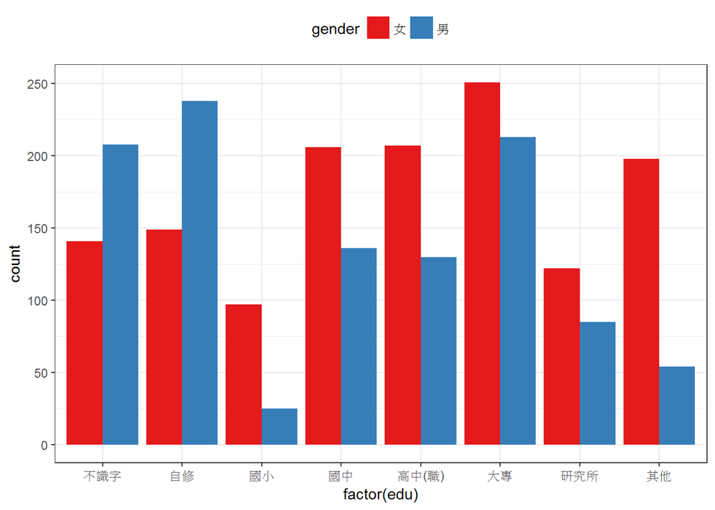

```r
a1<-a[1:47,]
ggplot(a1, aes(x=factor(edu), y=count,fill=gender)) +
  geom_bar(stat="identity",position = "dodge")+
  scale_fill_brewer(palette="Set1")+
  theme(legend.position="top")
```

再看看統計至民國103年的嫌疑犯人數情形

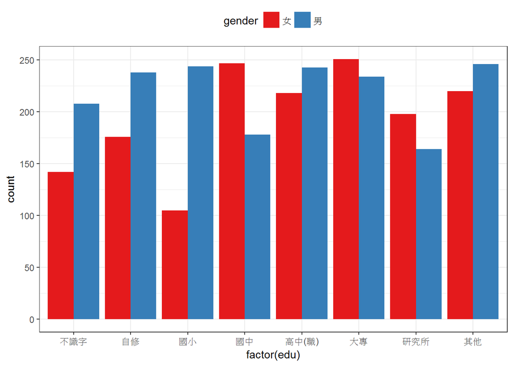

```r
ggplot(a, aes(x=factor(edu), y=count,fill=gender)) +
  geom_bar(stat="identity",position = "dodge")+
  scale_fill_brewer(palette="Set1")+
  theme(legend.position="top")
```

2.此資料因為影響的項目為類別資料(性別、教育程度)，受限而沒有使用相關係數與回歸來進一步分析，若未來有加入其他數值資料，則可探討在相同的教育程度下或相同性別下，另一數值變項每增加一單位對嫌疑犯人數的影響，便能掌握什麼變項影響最大